# sklearn.decomposition.FastICA

**class*sklearn.decomposition.FastICA(*n_components=None*, *, *algorithm='parallel'*, *whiten='warn'*, *fun='logcosh'*, *fun_args=None*, *max_iter=200*, *tol=0.0001*, *w_init=None*, *random_state=None*)[[source]](https://github.com/scikit-learn/scikit-learn/blob/f3f51f9b6/sklearn/decomposition/_fastica.py#L323)**

FastICA: a fast algorithm for Independent Component Analysis.

The implementation is based on [1].

Read more in the User Guide.

**Parameters:**

**n_components**int, default=None**

Number of components to use. If None is passed, all are used.

**algorithm**{‘parallel’, ‘deflation’}, default=’parallel’**

Specify which algorithm to use for FastICA.

**whiten**str or bool, default=”warn”**

Specify the whitening strategy to use.

- If ‘arbitrary-variance’ (default), a whitening with variance arbitrary is used.
- If ‘unit-variance’, the whitening matrix is rescaled to ensure that each recovered source has unit variance.
- If False, the data is already considered to be whitened, and no whitening is performed.

Deprecated since version 1.1: Starting in v1.3, `whiten='unit-variance'` will be used by default. `whiten=True` is deprecated from 1.1 and will raise ValueError in 1.3. Use `whiten=arbitrary-variance` instead.

**fun**{‘logcosh’, ‘exp’, ‘cube’} or callable, default=’logcosh’**

The functional form of the G function used in the approximation to neg-entropy. Could be either ‘logcosh’, ‘exp’, or ‘cube’. You can also provide your own function. It should return a tuple containing the value of the function, and of its derivative, in the point. The derivative should be averaged along its last dimension. Example:

```
def my_g(x):
    return x ** 3, (3 * x ** 2).mean(axis=-1)
```

**fun_args**dict, default=None**

Arguments to send to the functional form. If empty or None and if fun=’logcosh’, fun_args will take value {‘alpha’ : 1.0}.

**max_iter**int, default=200**

Maximum number of iterations during fit.

**tol**float, default=1e-4**

A positive scalar giving the tolerance at which the un-mixing matrix is considered to have converged.

**w_init**ndarray of shape (n_components, n_components), default=None**

Initial un-mixing array. If `w_init=None`, then an array of values drawn from a normal distribution is used.

**random_state**int, RandomState instance or None, default=None**

Used to initialize `w_init` when not specified, with a normal distribution. Pass an int, for reproducible results across multiple function calls. See [Glossary](https://scikit-learn.org/1.1/glossary.html#term-random_state).

**Attributes:**

**components_**ndarray of shape (n_components, n_features)**

The linear operator to apply to the data to get the independent sources. This is equal to the unmixing matrix when `whiten` is False, and equal to `np.dot(unmixing_matrix, self.whitening_)` when `whiten` is True.

**mixing_**ndarray of shape (n_features, n_components)**

The pseudo-inverse of `components_`. It is the linear operator that maps independent sources to the data.

**mean_**ndarray of shape(n_features,)**

The mean over features. Only set if `self.whiten` is True.

**n_features_in_**int**

Number of features seen during fit.

New in version 0.24.

**feature_names_in_**ndarray of shape (`n_features_in_`,)**

Names of features seen during fit. Defined only when `X` has feature names that are all strings.

New in version 1.0.

**n_iter_**int**

If the algorithm is “deflation”, n_iter is the maximum number of iterations run across all components. Else they are just the number of iterations taken to converge.

**whitening_**ndarray of shape (n_components, n_features)**

Only set if whiten is ‘True’. This is the pre-whitening matrix that projects data onto the first `n_components` principal components.

See also

**`PCA`**

Principal component analysis (PCA).

**`IncrementalPCA`**

Incremental principal components analysis (IPCA).

**`KernelPCA`**

Kernel Principal component analysis (KPCA).

**`MiniBatchSparsePCA`**

Mini-batch Sparse Principal Components Analysis.

**`SparsePCA`**

Sparse Principal Components Analysis (SparsePCA).

#### References

A. Hyvarinen and E. Oja, Independent Component Analysis: Algorithms and Applications, Neural Networks, 13(4-5), 2000, pp. 411-430.

#### Examples

```
>>> from sklearn.datasets import load_digits
>>> from sklearn.decomposition import FastICA
>>> X, _ = load_digits(return_X_y=True)
>>> transformer = FastICA(n_components=7,
...         random_state=0,
...         whiten='unit-variance')
>>> X_transformed = transformer.fit_transform(X)
>>> X_transformed.shape
(1797, 7)
```

#### Methods

| `fit`(X[, y]) | Fit the model to X. |
| --- | --- |
| `fit_transform`(X[, y]) | Fit the model and recover the sources from X. |
| `get_feature_names_out`([input_features]) | Get output feature names for transformation. |
| `get_params`([deep]) | Get parameters for this estimator. |
| `inverse_transform`(X[, copy]) | Transform the sources back to the mixed data (apply mixing matrix). |
| `set_params`(**params) | Set the parameters of this estimator. |
| `transform`(X[, copy]) | Recover the sources from X (apply the unmixing matrix). |

**fit(*X*, *y=None*)[[source]](https://github.com/scikit-learn/scikit-learn/blob/f3f51f9b6/sklearn/decomposition/_fastica.py#L662)**

Fit the model to X.

**Parameters:**

**X**array-like of shape (n_samples, n_features)**

Training data, where `n_samples` is the number of samples and `n_features` is the number of features.

**y**Ignored**

Not used, present for API consistency by convention.

**Returns:**

**self**object**

Returns the instance itself.

**fit_transform(*X*, *y=None*)[[source]](https://github.com/scikit-learn/scikit-learn/blob/f3f51f9b6/sklearn/decomposition/_fastica.py#L642)**

Fit the model and recover the sources from X.

**Parameters:**

**X**array-like of shape (n_samples, n_features)**

Training data, where `n_samples` is the number of samples and `n_features` is the number of features.

**y**Ignored**

Not used, present for API consistency by convention.

**Returns:**

**X_new**ndarray of shape (n_samples, n_components)**

Estimated sources obtained by transforming the data with the estimated unmixing matrix.

**get_feature_names_out(*input_features=None*)[[source]](https://github.com/scikit-learn/scikit-learn/blob/f3f51f9b6/sklearn/base.py#L909)**

Get output feature names for transformation.

**Parameters:**

**input_features**array-like of str or None, default=None**

Only used to validate feature names with the names seen in `fit`.

**Returns:**

**feature_names_out**ndarray of str objects**

Transformed feature names.

**get_params(*deep=True*)[[source]](https://github.com/scikit-learn/scikit-learn/blob/f3f51f9b6/sklearn/base.py#L194)**

Get parameters for this estimator.

**Parameters:**

**deep**bool, default=True**

If True, will return the parameters for this estimator and contained subobjects that are estimators.

**Returns:**

**params**dict**

Parameter names mapped to their values.

**inverse_transform(*X*, *copy=True*)[[source]](https://github.com/scikit-learn/scikit-learn/blob/f3f51f9b6/sklearn/decomposition/_fastica.py#L710)**

Transform the sources back to the mixed data (apply mixing matrix).

**Parameters:**

**X**array-like of shape (n_samples, n_components)**

Sources, where `n_samples` is the number of samples and `n_components` is the number of components.

**copy**bool, default=True**

If False, data passed to fit are overwritten. Defaults to True.

**Returns:**

**X_new**ndarray of shape (n_samples, n_features)**

Reconstructed data obtained with the mixing matrix.

**set_params(**params)[[source]](https://github.com/scikit-learn/scikit-learn/blob/f3f51f9b6/sklearn/base.py#L218)**

Set the parameters of this estimator.

The method works on simple estimators as well as on nested objects (such as `Pipeline`). The latter have parameters of the form `<component>__<parameter>` so that it’s possible to update each component of a nested object.

**Parameters:**

**paramsdict**

Estimator parameters.

**Returns:**

**self**estimator instance**

Estimator instance.

**transform(*X*, *copy=True*)[[source]](https://github.com/scikit-learn/scikit-learn/blob/f3f51f9b6/sklearn/decomposition/_fastica.py#L682)**

Recover the sources from X (apply the unmixing matrix).

**Parameters:**

**X**array-like of shape (n_samples, n_features)**

Data to transform, where `n_samples` is the number of samples and `n_features` is the number of features.

**copy**bool, default=True**

If False, data passed to fit can be overwritten. Defaults to True.

**Returns:**

**X_new**ndarray of shape (n_samples, n_components)**

Estimated sources obtained by transforming the data with the estimated unmixing matrix.

## Examples using `sklearn.decomposition.FastICA`

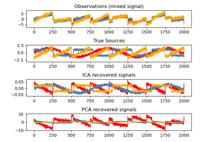

Blind source separation using FastICA

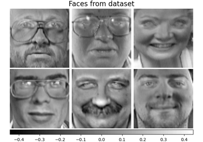

Faces dataset decompositions

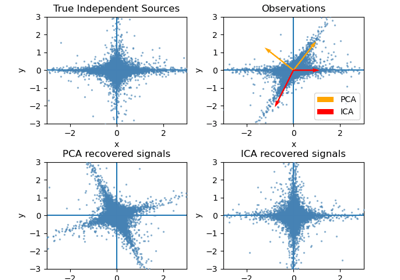

FastICA on 2D point clouds

© 2007–2022 The scikit-learn developers  
Licensed under the 3-clause BSD License.  
https://scikit-learn.org/1.1/modules/generated/sklearn.decomposition.FastICA.html